# Support Vector Machines

- Kernel Methods:
  - Supervised Learning
    - Kernel ridge regression
    - Kernel logistic regression
    - Large-margin classiﬁers
    - Interlude: convex optimization and duality
    - Support vector machines

## Motivation: A 1-D Example

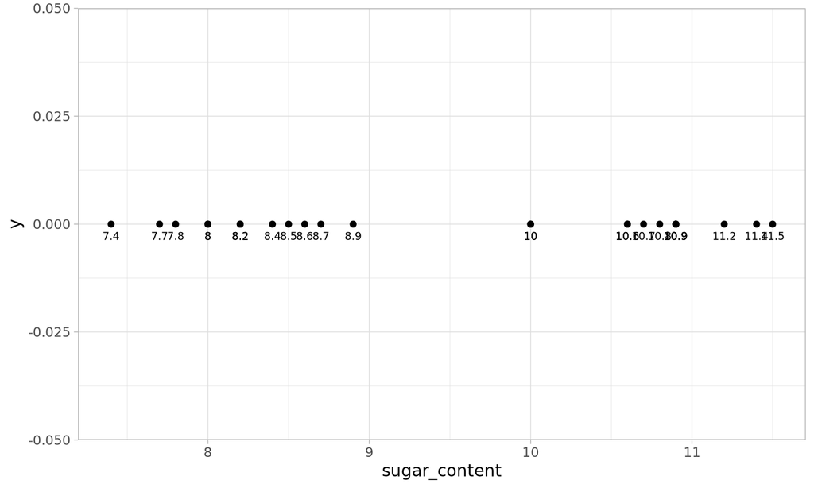

25 soft drink sugar content measurements. The distinct clusters for identifying candidate decision boundaries.

## The maximal margin separator

```r
mm_separator <- (8.9 + 10)/2
```

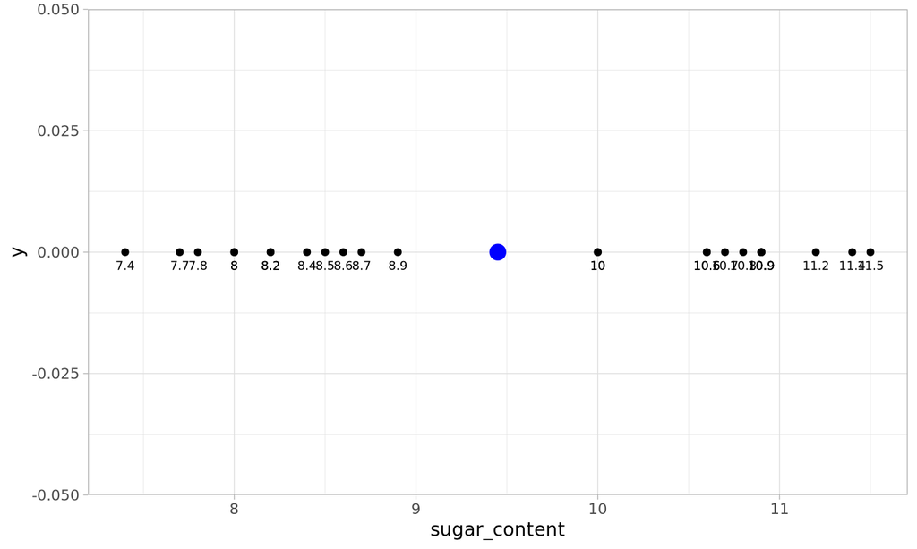

The maximal margin separator is at the midpoint of the two extreme points in each cluster.

## Find the maximal margin separator

Identified two distinct clusters (classes).

A dataset in which the classes do not overlap is called separable, the classes being separated by a decision boundary.

The maximal margin separator is the decision boundary that is furthest from both classes.

The relevant points are the highest valued point in the low sugar content class and the lowest valued point in the high sugar content class.

## Example 2: A 2d dataset.

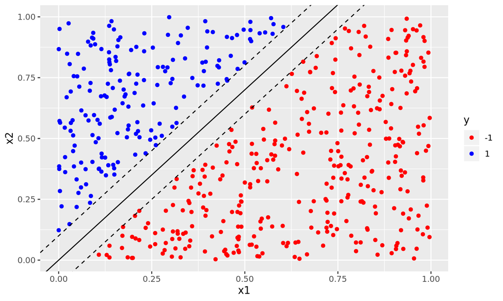

A decision boundary and a margin. Add a class variable to that dataset by creating a variable y whose value is -1 or +1 depending on whether the point (x1, x2) lies below or above the straight line that passes through the origin and has slope 1.4.

## Deﬁnition

Consider the \(\ell_2\) regularized empirical risk function

\[J(\vec{w}, \lambda)=\sum\limits{i=1}^N L(y_i, \hat{y_i})+\lambda\lVert\vec{w}\rVert^2\] where \(\hat{y_i}=\vec{w}^T\vec{x}_i+w_0\).

If \(L\) is quadratic loss, this is equivalent to ridge regression.  
If \(L\) is the log-loss, this is equivalent to logistic regression. If we replace the loss function with hinge loss function, we can ensure that the solution is sparse, so that predictions only depend on a subset of the training data, known as support vectors. This combination of the kernel trick plus a modified loss function is known as a **support vector machine** or SVM.

## Hinge Loss

Linear support vector machines can also be interpreted as hinge loss minimization: \[\min_{\vec{w},b} \sum\limits_{i=1}^N{L(y_i,f(\vec{x}_i))} + \lambda\|\vec{w}\|^2\] where \(L(y, f(\vec{x}))\) is a hinge loss function:

\[L(y, f(\vec{x})) = \begin{cases}1-yf(x), & 1-yf(x) > 0 \\0, & 1-yf(x) \leqslant 0\end{cases}\]

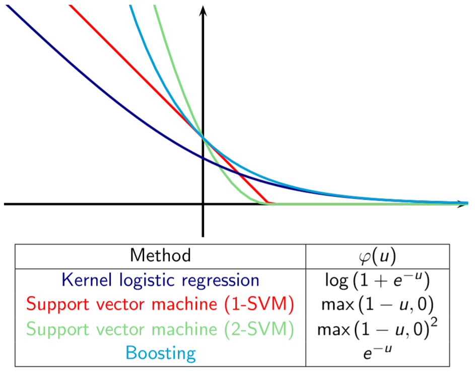

## Deﬁnition

The hinge loss is the function \(\mathbb{R}\to\mathbb{R}_+\):

\[\varphi_{hinge}(u) = \max(1-u,0) =\begin{cases}0 &\text{if } u\ge 1,\\ 1-u& \text{otherwise}. \end{cases}\]

SVM is the corresponding large-margin classiﬁer, which solves: \[\underset{f\in\mathcal{H}}{\min}\frac1n\sum_{i=1}^n\varphi_{hinge}(y_if(x_i)) + \lambda\|f\|^2_\mathcal{H}\]

## Support vectors

The training points with \(\alpha_i\neq0\) are called support vectors. Only support vectors are important for the classiﬁcation of new points:

\[\forall x\in\mathcal{X},\ f (x) =\sum_{i=1}^n\alpha_i K (x_i,x)=\sum_{i\in SV}\alpha_i K (x_i,x) \] where SV is the set of support vectors.

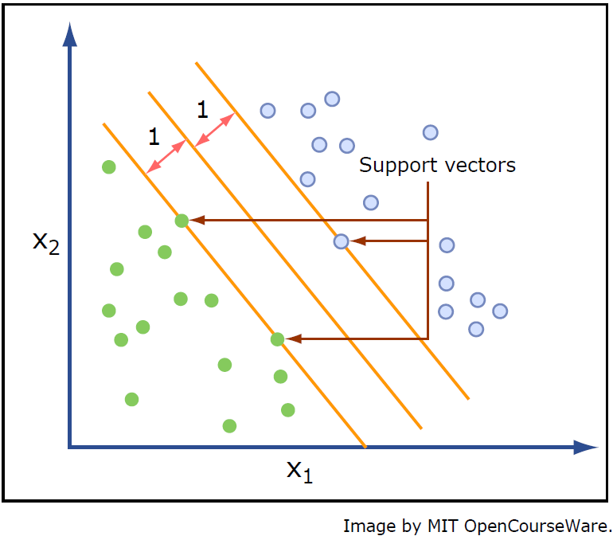

## Primal form

Representation

\[\mathcal{H}:y=f(\vec{x})=\text{sign}(\vec{w}\vec{x}+b)\]

Evaluation

\[\min_{\vec{w},b} \frac{1}{2}\|\vec{w}\|^2\quad \text{s.t.}\quad y_i(\vec{w}\vec{x}_i+b)\geqslant 1, i=1,2, \dots , N\]

## Primal form

By the representer theorem, the solution satisfies \[\hat f (x) =\sum_{i=1}^n\hat\alpha_i K (x_i,x) \], where \(\hat\alpha\) solves

\[\underset{\alpha\in\mathbb{R^n}}{\min}\frac1n\sum_{i=1}^n\varphi_{hinge}(y_i[K\alpha]_i) + \lambda\alpha^TK\alpha\]

This is a convex optimization problem But the objective function is not smooth (because of the hinge loss)

## Dual form

Representation \(\mathcal{H}:y=f(\vec{x})=\text{sign}\left(\sum\limits_{i=1}^N{\alpha_iy_i(\vec{x} \cdot \vec{x}_i)}+b\right)\)

Evaluation \[\min_{\alpha} \frac{1}{2} \sum\limits_{i=1}^N\sum\limits_{j=1}^N \alpha_i\alpha_j y_i y_j (\vec{x}_i \cdot \vec{x}_j) - \sum\limits_{i=1}^N \alpha_i\] s.t. \(\sum\limits_{i=1}^N\alpha_i y_i=0\quad \alpha_i \geqslant 0, i=1,2, \dots, N\)

\[\underset{\alpha\in\mathbb{R^n}}{\max}2\sum_{i=1}^n\alpha_i y_i -\sum_{i,j=1}^n\alpha_i\alpha_j K(x_i,x_j)=2\alpha^Ty-\alpha^TK\alpha\] subject to: \(0\le y_i\alpha_i\le\frac1{2\lambda n}, \text{for } i = 1,...,n\)

## Slack variables

Let us introduce additional slack variables \(\xi_1,...,\xi_n\in\mathbb{R}\). The problem is equivalent to:

\[\underset{\alpha\in\mathbb{R^n},\xi\in\mathbb{R^n}}{\min}\left\{\frac1n\sum_{i=1}^n\xi_i + \lambda\alpha^TK\alpha\right\}\] subject to: \[\xi_i\ge \varphi_{hinge}(y_i[K\alpha]_i)\] The objective function is now smooth, but not the constraints However it is easy to replace the non-smooth constraint by a cunjunction of two smooth constraints, because:

\[u \ge\varphi_{hinge}(v)\iff \begin{cases}u\ge 1-v \\u\ge 0\end{cases}\]

## slack variables

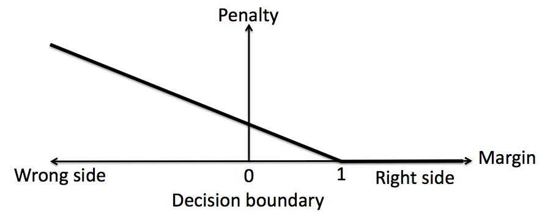

The solution is sparse in \(\alpha\), leading to fast algorithms for training (use of decomposition methods).

The classiﬁcation of a new point only involves kernel evaluations with support vectors (fast).

## Slack variables

Representation \(\mathcal{H}:y=f(\vec{x})=\text{sign}(\vec{w}\vec{x}+b)\)

Evaluation \(\min_{\vec{w},b} C \sum\limits_{i=1}^N\xi_i + \frac{1}{2}\|\vec{w}\|^2\)

s.t. \[ y_i(\vec{w}\vec{x}_i+b)\geqslant 1-\xi_i\quad \xi_i \geqslant 0, \quad i=1,2, \dots, N \]

the SVM solution is \(\hat f (x) =\sum_{i=1}^n\hat\alpha_i K (x_i,x)\),

where \(\hat\alpha\) solves: \(\underset{\alpha\in\mathbb{R^n},\xi\in\mathbb{R^n}}{\min}\left\{\frac1n\sum_{i=1}^n\xi_i + \lambda\alpha^TK\alpha\right\}\)

subject to: \(\begin{cases}(y_i[K\alpha]_i +\xi_i -1\ge 0,& \text{for} i = 1,...,n,\\\xi_i\ge 0,& \text{for} i = 1,...,n\end{cases}\)

## Soft margin classifiers and nonseparatable Data

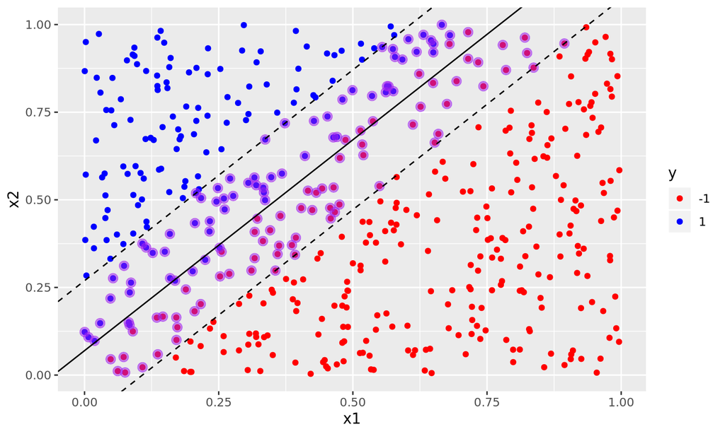

## C-SVM

Often the SVM optimization problem is written in terms of a regularization parameter \(C\) instead of \(\lambda\) as follows:

\[\underset{f\in\mathcal{H}}{\arg\min}\left\{\frac12\|f\|^2_\mathcal{H}+C\sum_{i=1}^nL_{hinge}(f(x_i),y_i)\right\}\]

This is equivalent to our formulation with \(C=\frac1{2\lambda n}\).

The SVM optimization problem is then:

\[\underset{\alpha\in\mathbb{R^d}}{\max}\left\{2\sum_{i=1}^n\alpha_i y_i -\sum_{i,j=1}^n\alpha_i\alpha_j K(x_i,x_j)\right\}\]

subject to: \(0\le y_i\alpha_i\le C, \text{for } i = 1,...,n\) This formulation is often called C-SVM.

## C-SVM

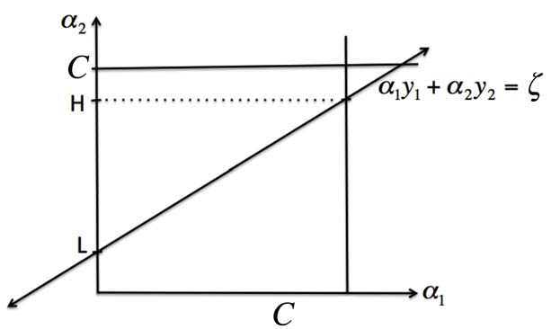

## 2-SVM

A variant of the SVM, sometimes called 2-SVM, is obtained by replacing the hinge loss by the square hinge loss:

\[\underset{f\in\mathcal{H}}{\min}\left\{\frac1n\sum_{i=1}^n\varphi_{hinge}(y_if(x_i))^2 + \lambda\|f\|^2_\mathcal{H}\right\}\]

The dual problem of the 2-SVM is:

\[\underset{\alpha\in\mathbb{R^d}}{\max}\left\{2\alpha^Ty-\alpha^T(K+n\lambda I)\alpha\right\}\] \[0\le y_i\alpha_i,\ \text{for } i = 1,...,n\]

This is therefore equivalent to the previous SVM with the kernel \(K + n\lambda I\) and \(C=+\infty\)

## A radially 2d non-linear Example

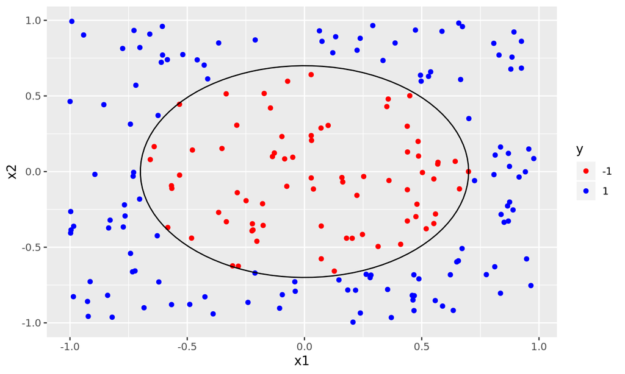

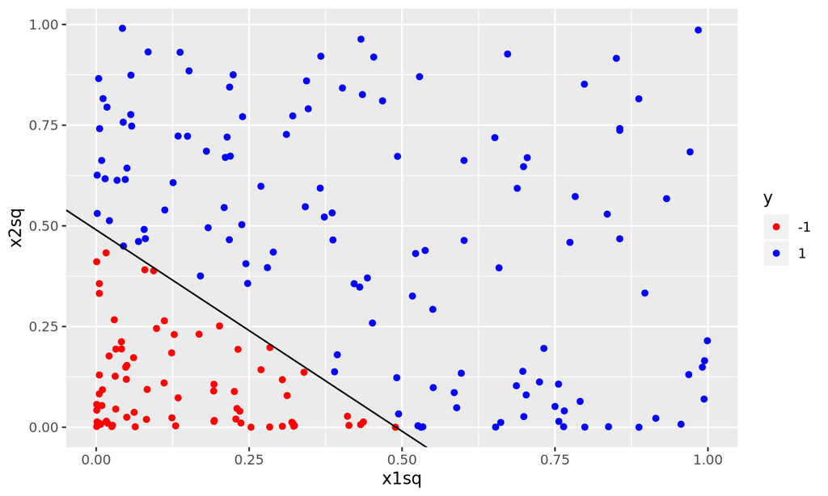

2 predictors x1 and x2, uniformly distributed between -1 and 1.

```
## [1] 0.949
```

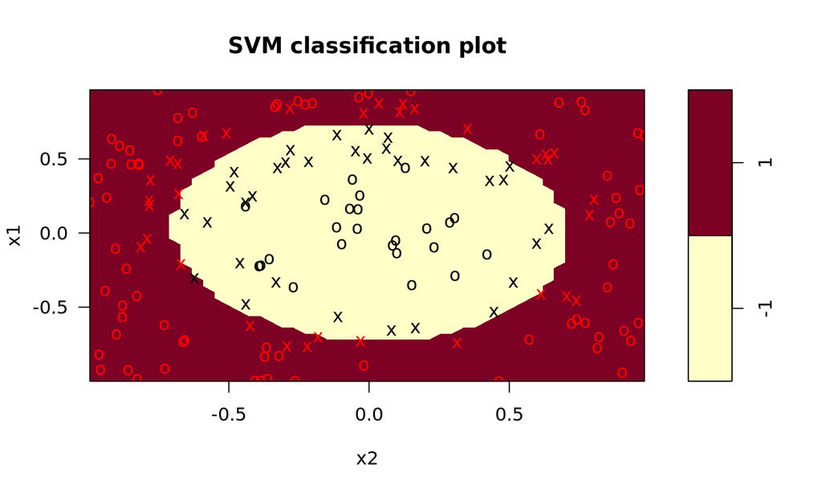

## A more complex Example

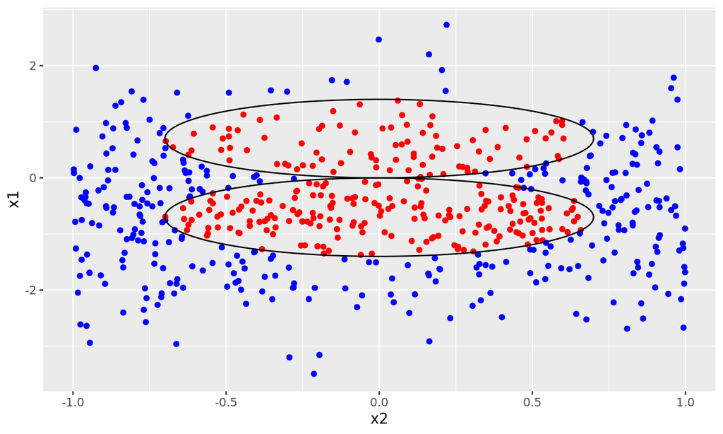

600 points (x1,x2) x1 and x2 distributed differently

```
## [1] 0.964
```

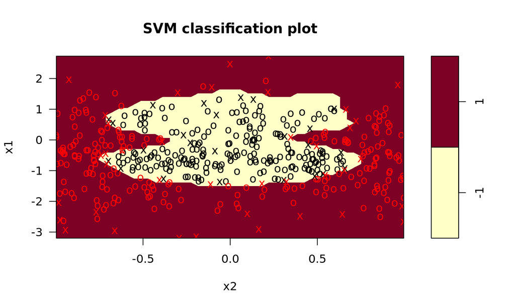

## Note

Historically the ﬁrst “kernel method” for pattern recognition, still the most popular.

Often state-of-the-art in performance.

One particular choice of loss function (hinge loss).

Leads to a sparse solution, i.e., not all points are involved in the decomposition (compression).

Particular algorithm for fast optimization (decomposition by chunking methods).

## Summary

SVM classiﬁers involve three key ingredients: the kernel trick, sparsity, and the large margin principle .

The kernel trick is necessary to prevent underﬁtting, i.e., to ensure that the feature vector is sufﬁciently rich that a linear classiﬁer can separate the data.

If the original features are already high dimensional, it suffices to use a linear kernel, \(K(x,x') = x^Tx'\) , which is equivalent to working with the original features.

The sparsity and large margin principles are necessary to prevent overfitting, i.e., to ensure that we do not use all the basis functions. These two ideas are closely related to each other,and both arise (in this case) from the use of the hinge loss function.

However, there are other methods of achieving sparsity (such as \(\ell_1\)), and also other methods of maximizing the margin(such as boosting).

## Experiments

Chapelle, O. (2007). Training a support vector machine in the primal. Neural computation, 19(5), 1155-1178.

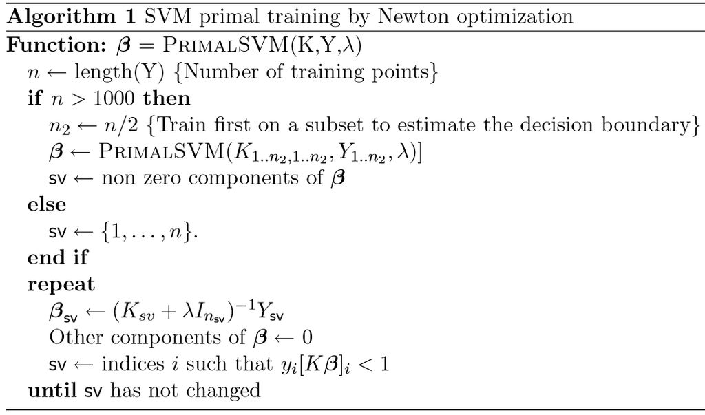

[figure not shown]